# TÓPICOS EM ESTATÍSTICA 1 - 1º/2022

Prof. Guilherme Rodrigues

## SparklyR (modelagem de dados)

Nesta ilustração, o será configurado para utilizar boa parte da capacidade de hardware deste computador pessoal: 6 núcleos executores e 12 GB de RAM.

```r
# Carregando os pacotes usados
pacman::p_load(sparklyr, tidyverse)

# Conectando a um cluster spark local
config <- spark_config()
config$spark.executor.cores <- 6
config$spark.executor.memory <- "12G"
sc <- spark_connect(master = "local", config = config)
```

### Direcionando local dos arquivos:

```r
# Listando os arquivos considerados
path <- ".\\titanic"
list.files(path)
```

```
## [1] "test.csv"  "train.csv"
```

## Leitura dos dados:

```r
# Carregando os dados para o cluster spark
{start <- Sys.time()
titanic_tbl = spark_read_csv(sc=sc,
                             name = "titanic_tbl",
                             path = file.path(path,"train.csv"),
                             header = TRUE,
                             delimiter = ",",
                             charset = "latin1",
                             infer_schema = T)
spark_data_read_time <- Sys.time() - start
}

{tm <- sum(file.size(file.path(path,"train.csv"))/(10^3))
print(paste("Levou",
            round(spark_data_read_time, digits = 2),
            units(spark_data_read_time),
            "para carregar o conjunto de dados de",
            round(tm),
            "KB no SparklyR"))
}
```

```
## [1] "Levou 9.08 secs para carregar o conjunto de dados de 61 KB no SparklyR"
```

## Dicionário de Variáveis

| Nome | Descrição |
| --- | --- |
| PassengerID: | Número de identificação do passageiro; |
| Survived: | Informa se o passageiro sobreviveu ao naufrágio (0 = não e 1 = sim); |
| Pclass: | Classe do bilhete (1 = “1ª classe”; 2 = “2ª classe” e 3 = “3ª classe”); |
| Name: | Nome do passageiro; |
| Sex: | Sexo do passageiro; |
| Age: | Idade do passageiro; |
| SibSp: | Quantidade de cônjuges e/ou irmãos a bordo; |
| Parch: | Quantidade de pais e filhos a bordo; |
| Ticket: | Número da passagem; |
| Fare: | Preço da passagem; |
| Cabin: | Número da cabine do passageiro; |
| Embarked: | Porto de embarque: (C = Cherbourg; Q = Queenstown; S = Southampton). |

## Análise exploratória:

### Verificando a dimensão e a completude da tabela

```r
# Dimensão e atributos da tabela
sdf_dim(titanic_tbl) # semelhante a funçao dim() porém no ambiente spark
```

```
## [1] 891  12
```

```r
sdf_describe(titanic_tbl) # semelhante a funçao summary() porém no ambiente spark
```

| summary | PassengerId | Survived | Pclass | Name | Sex | Age | SibSp | Parch | Ticket | Fare | Cabin | Embarked |
| --- | --- | --- | --- | --- | --- | --- | --- | --- | --- | --- | --- | --- |
| count | 891 | 891 | 891 | 891 | 891 | 714 | 891 | 891 | 891 | 891 | 204 | 889 |
| mean | 446.0 | 0.3838383838383838 | 2.308641975308642 | NA | NA | 29.69911764705882 | 0.5230078563411896 | 0.38159371492704824 | 260318.54916792738 | 32.2042079685746 | NA | NA |
| stddev | 257.3538420152301 | 0.48659245426485753 | 0.8360712409770491 | NA | NA | 14.526497332334035 | 1.1027434322934315 | 0.8060572211299488 | 471609.26868834975 | 49.69342859718089 | NA | NA |
| min | 1 | 0 | 1 | "Andersson, Mr. August Edvard (""Wennerstrom"")" | female | 0.42 | 0 | 0 | 110152 | 0.0 | A10 | C |
| max | 891 | 1 | 3 | van Melkebeke, Mr. Philemon | male | 80.0 | 8 | 6 | WE/P 5735 | 512.3292 | T | S |

```r
glimpse(titanic_tbl)
```

```
## Rows: ??
## Columns: 12
## Database: spark_connection
## $ PassengerId <int> 1, 2, 3, 4, 5, 6, 7, 8, 9, 10, 11, 12, 13, 14, 15, 16, 17,~
## $ Survived    <int> 0, 1, 1, 1, 0, 0, 0, 0, 1, 1, 1, 1, 0, 0, 0, 1, 0, 1, 0, 1~
## $ Pclass      <int> 3, 1, 3, 1, 3, 3, 1, 3, 3, 2, 3, 1, 3, 3, 3, 2, 3, 2, 3, 3~
## $ Name        <chr> "Braund, Mr. Owen Harris", "Cumings, Mrs. John Bradley (Fl~
## $ Sex         <chr> "male", "female", "female", "female", "male", "male", "mal~
## $ Age         <dbl> 22, 38, 26, 35, 35, NA, 54, 2, 27, 14, 4, 58, 20, 39, 14, ~
## $ SibSp       <int> 1, 1, 0, 1, 0, 0, 0, 3, 0, 1, 1, 0, 0, 1, 0, 0, 4, 0, 1, 0~
## $ Parch       <int> 0, 0, 0, 0, 0, 0, 0, 1, 2, 0, 1, 0, 0, 5, 0, 0, 1, 0, 0, 0~
## $ Ticket      <chr> "A/5 21171", "PC 17599", "STON/O2. 3101282", "113803", "37~
## $ Fare        <dbl> 7.2500, 71.2833, 7.9250, 53.1000, 8.0500, 8.4583, 51.8625,~
## $ Cabin       <chr> NA, "C85", NA, "C123", NA, NA, "E46", NA, NA, NA, "G6", "C~
## $ Embarked    <chr> "S", "C", "S", "S", "S", "Q", "S", "S", "S", "C", "S", "S"~
```

```r
# Verificando a quantidade de observações faltantes por variável
titanic_tbl %>%
  summarise_all(~sum(as.integer(is.na(.))))
```

| PassengerId | Survived | Pclass | Name | Sex | Age | SibSp | Parch | Ticket | Fare | Cabin | Embarked |
| --- | --- | --- | --- | --- | --- | --- | --- | --- | --- | --- | --- |
| 0 | 0 | 0 | 0 | 0 | 177 | 0 | 0 | 0 | 0 | 687 | 2 |

Nossa variavel resposta, `Survided`, varia em função das covariáveis do banco; por exemplo, percebe-se que as mulheres tinham maior probabilidade de sobreviver ao desastre.

```r
# Calculando a proporção de sobreviventes por sexo biológico
titanic_tbl %>%
  group_by(Sex,Survived) %>%
  tally() %>%
  mutate(frac = round(n / sum(n),2)) %>%
  arrange(Sex,Survived)
```

| Sex | Survived | n | frac |
| --- | --- | --- | --- |
| female | 0 | 81 | 0.26 |
| female | 1 | 233 | 0.74 |
| male | 0 | 468 | 0.81 |
| male | 1 | 109 | 0.19 |

Analisando a localidade de embarque dos viajantes, vemos que existe uma ligeira diferença entre as taxas de sobrevicência.

```r
# Calculando a proporção de sobreviventes pelo local de embarque
titanic_tbl %>%
  group_by(Embarked,Survived) %>%
  tally() %>%
  mutate(frac = round(n / sum(n),2)) %>%
  arrange(Embarked,Survived)
```

| Embarked | Survived | n | frac |
| --- | --- | --- | --- |
| NA | 1 | 2 | 1.00 |
| C | 0 | 75 | 0.45 |
| C | 1 | 93 | 0.55 |
| Q | 0 | 47 | 0.61 |
| Q | 1 | 30 | 0.39 |
| S | 0 | 427 | 0.66 |
| S | 1 | 217 | 0.34 |

### Distribuições de variáveis.

Podemos análisar a distribuição de algumas variaveis usando este comando ou usando collect+ggplot2.

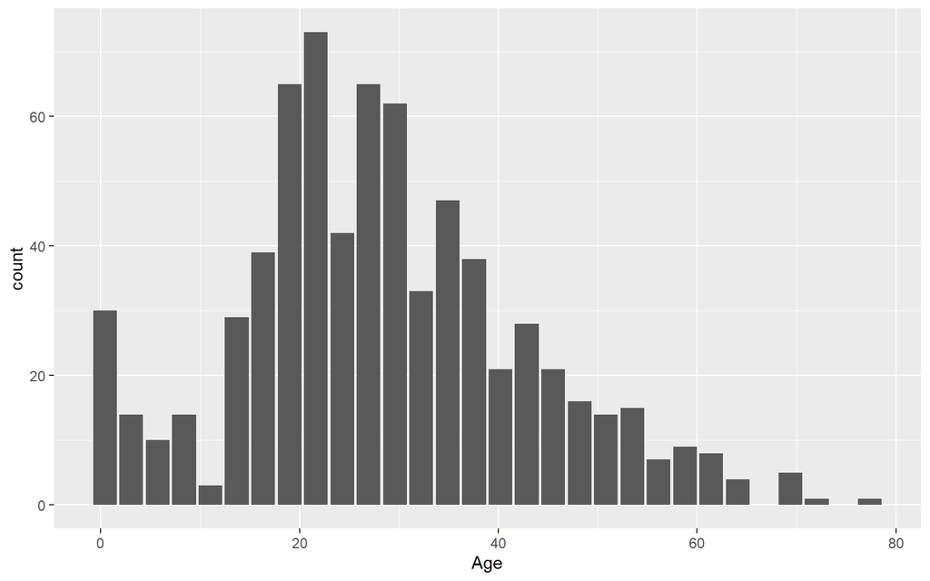

```r
# Criando um histograma da variável Idade
library(dbplot)
options(scipen = 999)
dbplot_histogram(titanic_tbl, Age)
```

## Preparando os dados para modelagem:

A fase de preparação consiste em selecionar e corrigir eventuais problemas na tabela. Como visto anteriormente, a variável **Age** apresenta inúmeros dados faltantes (NA). Para não descartar todas as respectivas linhas (o que possivelmente levaria a uma perda de desempenho preditivo), podemos fazer uma *inputação* ultilizando, por exemplo, o valor médio da variável.

```r
# Inputando a média para os dados faltantes da variável Age
model_tbl <- titanic_tbl %>%
  select(Survived, Pclass, Sex, Age, Fare, SibSp, Parch, Name, Embarked) %>%
  filter(!is.na(Embarked)) %>%
  mutate(Age = if_else(is.na(Age), mean(Age), Age))
glimpse(model_tbl)
```

```
## Rows: ??
## Columns: 9
## Database: spark_connection
## $ Survived <int> 0, 1, 1, 1, 0, 0, 0, 0, 1, 1, 1, 1, 0, 0, 0, 1, 0, 1, 0, 1, 0~
## $ Pclass   <int> 3, 1, 3, 1, 3, 3, 1, 3, 3, 2, 3, 1, 3, 3, 3, 2, 3, 2, 3, 3, 2~
## $ Sex      <chr> "male", "female", "female", "female", "male", "male", "male",~
## $ Age      <dbl> 22.00000, 38.00000, 26.00000, 35.00000, 35.00000, 29.64209, 5~
## $ Fare     <dbl> 7.2500, 71.2833, 7.9250, 53.1000, 8.0500, 8.4583, 51.8625, 21~
## $ SibSp    <int> 1, 1, 0, 1, 0, 0, 0, 3, 0, 1, 1, 0, 0, 1, 0, 0, 4, 0, 1, 0, 0~
## $ Parch    <int> 0, 0, 0, 0, 0, 0, 0, 1, 2, 0, 1, 0, 0, 5, 0, 0, 1, 0, 0, 0, 0~
## $ Name     <chr> "Braund, Mr. Owen Harris", "Cumings, Mrs. John Bradley (Flore~
## $ Embarked <chr> "S", "C", "S", "S", "S", "Q", "S", "S", "S", "C", "S", "S", "~
```

### Feature Engineering

Abaixo efetuaremos uma normalização dos dados de idade e dos preço das passagens.

```r
# Calculando as medidas necessárias para a normalização.
scale_values <- model_tbl %>%
  summarize(
    mean_Age = mean(Age),
    mean_Fare = mean(Fare),
    sd_Age = sd(Age),
    sd_Fare = sd(Fare)
  ) %>%
  collect()

# Normalizando as variáveis Age e Fare.
## Usamos !! ou local() para calcular os valores no R
model_tbl <- model_tbl %>%
  mutate(scaled_Age = (Age - local(scale_values$mean_Age)) /
           !!scale_values$sd_Age,
         scaled_Fare = (Fare - !!scale_values$mean_Fare) /
           !!scale_values$sd_Fare)

# Usando a função ft_standard_scaler ou ft_normalizer()
# teste <- model_tbl %>%
#   ft_vector_assembler(input_col = "Age",
#                       output_col = "Age_temp") %>%
#   ft_standard_scaler(input_col = "Age_temp",
#                 output_col = "Age_scaled2",
#                 with_mean = T) %>%
#   select(Age, Age_temp, scaled_Age, Age_scaled2) %>%
#   collect()
```

Às vezes algumas informações que podem ser de grande utilidade para o modelo não estão devidamente formatadas. Por exemplo, a variavel **Name** é textual, e, a partir dela, pode-se extrair a titularidade do viajante (Mr, Mrs, …).

```r
# Criando variáveis que codificam os títulos dos passageiros
title <- c("Master", "Miss", "Mr", "Mrs")

title_vars <- title %>%
  map(~ expr(ifelse(rlike(Name, !!.x), 1, 0))) %>%
  set_names(str_c("title_", title))

model_tbl <- model_tbl %>%
  mutate(local(title_vars),
    title_Mr = if_else(title_Mrs == 1, 0, title_Mr),
    title_officer = if_else(
      title_Mr == 0 && title_Mrs == 0 &&
        title_Master == 0 && title_Miss == 0, 1, 0))

model_tbl %>%
  select(starts_with("title"), Name)
```

| title_Master | title_Miss | title_Mr | title_Mrs | title_officer | Name |
| --- | --- | --- | --- | --- | --- |
| 0 | 0 | 1 | 0 | 0 | Braund, Mr. Owen Harris |
| 0 | 0 | 0 | 1 | 0 | Cumings, Mrs. John Bradley (Florence Briggs Thayer) |
| 0 | 1 | 0 | 0 | 0 | Heikkinen, Miss. Laina |
| 0 | 0 | 0 | 1 | 0 | Futrelle, Mrs. Jacques Heath (Lily May Peel) |
| 0 | 0 | 1 | 0 | 0 | Allen, Mr. William Henry |
| 0 | 0 | 1 | 0 | 0 | Moran, Mr. James |
| 0 | 0 | 1 | 0 | 0 | McCarthy, Mr. Timothy J |
| 1 | 0 | 0 | 0 | 0 | Palsson, Master. Gosta Leonard |
| 0 | 0 | 0 | 1 | 0 | Johnson, Mrs. Oscar W (Elisabeth Vilhelmina Berg) |
| 0 | 0 | 0 | 1 | 0 | Nasser, Mrs. Nicholas (Adele Achem) |

[output cut: 879 more lines]

## Particionando em bases de treinamento e teste:

Em modelagem, é essencial investigar o quão bem o modelo consegue prever novos dados. Para tanto, é importante avaliar o desempenho preditivo em uma parte do conjunto de dados que não tenha sido usada no processo de treinamento.

```r
# Particionando o conjunto de dados em treino e teste
partition <- model_tbl %>%
 sdf_random_split(training = 0.85, test = 0.15, seed = 1281)

# Create table references
data_training <- sdf_register(partition$train, "trips_train")
data_test <- sdf_register(partition$test, "trips_test")

# Cache
tbl_cache(sc, "trips_train")
tbl_cache(sc, "trips_test")
```

## Regressão logistica

A Regressão logistica é uma das classes de modelos mais usadas quando a variavel resposta é do tipo categorica.

A fórmula abaixo será ultilizada em nosso modelo; queremos saber se uma pessoa sobreviveu ao titanic (Survived) com base nas variaveis listadas após o simbolo ‘~’.

```r
formula <- ('Survived ~ Sex + scaled_Age + scaled_Fare + Pclass +
            SibSp + Parch + Embarked + title_Mr + title_Mrs + title_Miss +
            title_Master + title_officer')
```

Nosso modelo poderia ser feito com no `R` base desta forma:

```r
lr_model <- glm(formula,
                family = binomial(link='logit'),
                data = data_training)
summary(lr_model)
```

```
##
## Call:
## glm(formula = formula, family = binomial(link = "logit"), data = data_training)
##
## Deviance Residuals:
##     Min       1Q   Median       3Q      Max
## -2.3632  -0.5317  -0.3743   0.5272   2.4717
##
## Coefficients:
##                 Estimate Std. Error z value         Pr(>|z|)
## (Intercept)     -8.54120 1455.39770  -0.006          0.99532
## Sexmale        -16.00565  823.34628  -0.019          0.98449
## scaled_Age      -0.33281    0.12664  -2.628          0.00859 **
## scaled_Fare      0.07453    0.14086   0.529          0.59675
## Pclass          -1.18177    0.17000  -6.952 0.00000000000361 ***
## SibSp           -0.53695    0.13595  -3.950 0.00007826668619 ***
## Parch           -0.27311    0.15423  -1.771          0.07659 .
## EmbarkedQ       -0.10637    0.42657  -0.249          0.80309
## EmbarkedS       -0.46127    0.26717  -1.727          0.08425 .
## title_Mr        26.00134 1672.14873   0.016          0.98759
## title_Mrs       13.68835 1455.39757   0.009          0.99250
## title_Miss      12.97975 1455.39759   0.009          0.99288
## title_Master    29.45906 1672.14878   0.018          0.98594
## title_officer   25.76762 1672.14862   0.015          0.98771
## ---
## Signif. codes:  0 '***' 0.001 '**' 0.01 '*' 0.05 '.' 0.1 ' ' 1
##
## (Dispersion parameter for binomial family taken to be 1)
##
##     Null deviance: 1001.83  on 750  degrees of freedom
## Residual deviance:  604.64  on 737  degrees of freedom
## AIC: 632.64
##
## Number of Fisher Scoring iterations: 14
```

Abaixo usaremos o modelo criado para prever a variável Survived no conjunto **data_test**. Vemos que o modelo acertou 84% das observações.

```r
# Prevendo os dados no conjunto de teste
pred.test <- predict(lr_model, data_test) > 0

# Calculando o percentual de acertos
mean(pred.test == data_test %>% pull(Survived)) # Percentual de acertos
```

```
## [1] 0.8405797
```

```r
table(pred.test, data_test %>% pull(Survived)) # matrix de confusão
```

```
##
## pred.test  0  1
##     FALSE 80 14
##     TRUE   8 36
```

## Regressão logistica usando as funçoes do sparklyr

```r
lr2_model <- data_training %>%
  ml_logistic_regression(formula)
```

### Avaliando o modelo

```r
# Prevendo usando o spark - Predict()
validation_summary <- ml_evaluate(lr2_model, data_test)

roc <- validation_summary$roc() %>%
  collect()

validation_summary$area_under_roc()
```

```
## [1] 0.8411364
```

### Gráfico

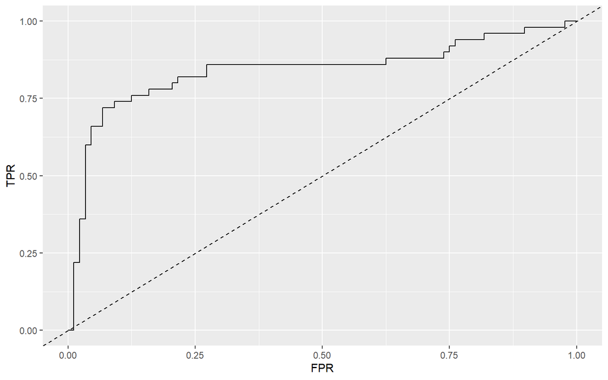

```r
ggplot(roc, aes(x = FPR, y = TPR)) +
  geom_line() + geom_abline(lty = "dashed")
```